# FigureYa45 iCluster的教程答疑V2

Zhougeng Xu, Taojun Ye

2025-05-20

[figure not shown]

## 版本更新

在原来的基础上，增加和修改了如下几处内容：

- 修改了R 3.5.0以后的安装方法(保留低于R 3.5.0之前的安装方法)
- 增加重要参数的说明
- 将`iClusterPlus`替换成最新的`iClusterBayes`
- 增加了结果输出部分，用于调用其他R包做热图
- 增加了几个统计学和机器学习概念的解释

##Version update

On the basis of the original, the following contents have been added and modified:

-Modified the installation method after R 3.5.0 (retaining the installation method before R 3.5.0) -Add an explanation of important parameters -Replace ‘iClusterPlus’ with the latest’ iClusterBayes’` -Added a result output section for calling other R packages to create heat maps -Added explanations for several statistical and machine learning concepts

## 需求描述

iCluster分析过程答疑。

另外，需要输出分类和特征基因，用于画paper里的这种热图。

##Requirement description

Q&A on the iCluster analysis process.

In addition, it is necessary to output classification and feature genes for drawing such heat maps in the paper.

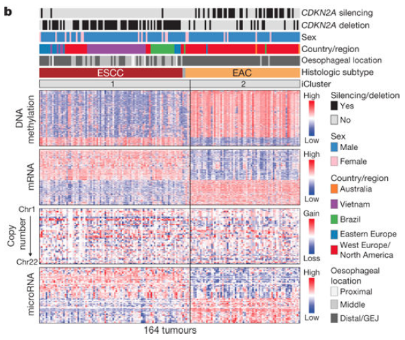

出自https://www.nature.com/articles/nature20805

fromhttps://www.nature.com/articles/nature20805

可以用`FigureYa17已分类的heatmap`来画heatmap，从本代码输出的`output_clusterMembership.txt`中取一列分类，作为sample分组信息。例图iCluster的两类完全分开，为了达到这种效果，需要单独画1类和2类，然后拼在一起。

You can use the ‘FigureYa17 Classified Heatmap’ to draw a heatmap, and take a column of classification from the ‘Output_clusterMembership. txt’ output of this code as the sample grouping information. The two types of iCluster in the example diagram are completely separated. To achieve this effect, it is necessary to draw Class 1 and Class 2 separately and then assemble them together.

## 应用场景

使用iClusterPlus整合多种基因组数据。

肿瘤的分子复杂性体现在基因组、表观组、转录组和蛋白组等多种水平。

一种方法是单独对不同数据类型进行聚类，然后手动合并。而`iCluster`则是同时使用多种来源数据进行整合分析，用于识别肿瘤亚型。

`iCluster`在2009年开发，中间经历了很多次的开发升级，目前最新版是Bioconductor上的`iClusterPlus`, 包括`iClusterPlus`和`iClusterBayes`两种算法。三者的区别在于:

- iCluster(2009): 使用lasso限制的隐变量回归识别可用于聚类的常见隐变量(common latent variable)
- iClusterPlus(2012): 整合了elasticnet和fused lasso算法, 可以处理ontinuous, count, binary, multi-categorical类数据
- iClusterBayes(2018): 改进了算法，比iClusterPlus速度快

> 隐变量(latent variable)是一个机器学习中的概念。举例说明，如果一个人面前有三个袋子，他每次抽球的时候都会说自己是从哪个袋子里拿了哪种颜色的球，你在旁边记录每个袋子抽出了什么颜色的球，在他抽取一定次数后，你就能估计每个袋子中不同颜色球的比例。但是如果他最后只汇报他抽的是什么颜色的球，而将从哪个袋子抽球的这一步**隐藏**了，那么选袋子这一步就是隐变量。广义上的隐变量主要就是指”不能被直接观察到，但是对系统的状态和能观察到的输出存在影响的一种东西”

> lasso, elastic net, fused lasso 是机器学习中特征选择的实现算法, 也就是找到数据集中有代表性的属性(attribute)。

##Application scenarios

Integrate multiple genomic data using iClusterPlus.

The molecular complexity of tumors is reflected at various levels such as genome, epigenome, transcriptome, and proteome.

One method is to cluster different data types separately and then manually merge them. And ‘iCluster’ integrates and analyzes data from multiple sources simultaneously to identify tumor subtypes.

`ICluster was developed in 2009 and has undergone many development upgrades. The latest version is iCluster Plus on Bioconductor, which includes two algorithms: iCluster Plus and iCluster Bayes. The difference between the three is that:

-ICluster (2009): Identification of common latent variables that can be used for clustering using lasso restricted latent variable regression -IClusterPlus (2012): integrates elasticnet and fused lasso algorithms to handle continuous, count, binary, and multi categorical data -IClusterBayes (2018): Improved algorithm, faster than iClusterPlus

> Latent variable is a concept in machine learning. For example, if a person has three bags in front of them, every time they draw a ball, they will say which bag they took a ball of which color from. You can record the color of the ball drawn from each bag next to them, and after they draw a certain number of times, you can estimate the proportion of balls of different colors in each bag. But if he only reports what color of ball he drew in the end and hides which bag he drew the ball from, then the step of selecting the bag is a hidden variable. In a broad sense, latent variables mainly refer to “something that cannot be directly observed, but has an impact on the system’s state and observable output”

> Lasso, elastic net, fused lasso is an implementation algorithm for feature selection in machine learning, which involves finding representative attributes in a dataset.

## 环境准备

### 安装iClusterPlus

`iClusterPlus`需要通过`biocLite`安装，如果速度慢，将下面代码`#options(...)`中的`#`去掉，则会使用国内镜像.

CRAN镜像备选

- 国科大: https://mirrors.ustc.edu.cn/CRAN/
- 同济大学: https://mirrors.tongji.edu.cn/CRAN/
- 兰州大学: https://mirror.lzu.edu.cn/CRAN/

##Environmental preparation

###Install iClusterPlus

`IClusterPlus needs to be installed through biocLite. If the speed is slow, remove the # from the # options (…) code below, and a domestic image will be used

CRAN image backup

-University of Science and Technology of China:< https://mirrors.ustc.edu.cn/CRAN/ > -Tongji University:< https://mirrors.tongji.edu.cn/CRAN/ > -Lanzhou University:< https://mirror.lzu.edu.cn/CRAN/ >

```r
#options("repos"= c(CRAN="https://mirrors.tuna.tsinghua.edu.cn/CRAN/"))
#options(BioC_mirror="http://mirrors.ustc.edu.cn/bioc/")
# R版本大于3.5.0时的安装方法
# Installation method for R version > 3.5.0
if (!requireNamespace("BiocManager"))
    install.packages("BiocManager")
# 检查是否安装了iClusterPlus包，若未安装则通过BiocManager安装
# Check if the iClusterPlus package is installed, if not, install it via BiocManager
if (!requireNamespace("iClusterPlus"))
  BiocManager::install("iClusterPlus")
#R版本小于3.5.0时的安装方法（已注释）
# Installation method for R version < 3.5.0 (commented out)
#source("http://bioconductor.org/biocLite.R")
#biocLite("iClusterPlus")
# 加载iClusterPlus包
# Load the iClusterPlus package
library("iClusterPlus")
```

### 其他工具

###Other tools

```r
# 安装DNAcopy和GenomicRanges包（已注释，避免重复安装）
# Install DNAcopy and GenomicRanges packages (commented to avoid reinstallation)
#BiocManager::install("DNAcopy")
#BiocManager::install("GenomicRanges")
# R < 3.5.0版本的安装方法（已注释）
# Installation method for R < 3.5.0 (commented out)
#source("http://bioconductor.org/biocLite.R")
#biocLite("DNAcopy")
#biocLite("GenomicRanges")

# 加载DNAcopy包 - 用于DNA拷贝数变异分析
# Load the DNAcopy package - for DNA copy number variation analysis
library("DNAcopy")

# 加载GenomicRanges包 - 用于处理基因组区间数据
# Load the GenomicRanges package - for handling genomic interval data
library("GenomicRanges")
```

## 输入数据

`iClusterPlus`和`iClusterBayes`支持如下类型数据:

- binary: 如体细胞变异, 有(1)/无(0)
- catergorical: 拷贝数状态: -2 = homozygous deletion; -1 = hemizygous deletion; 0 = neutral / no change; 1 = gain; 2 = high level amplification
- counts: 如RNA-seq count
- continuous: 如芯片表达量数据

测试数据集为TCGA的GBM(glioblastoma, 胶质母细胞瘤)数据集, 可以从http://www.cbioportal.org/ 和 https://portal.gdc.cancer.gov/ 中下载. - gbm_mut.txt: 体细胞突变数据. 来自于三个芯片平台(Agilent 244K, SNP6, Illumina 550K), 0表示无，1表示有 - gbm_exp.txt: 来自于不同平台的基因表达量归一化后数据 - gbm_seg.txt: DNA 拷贝数变异. Level 3经标准化和片段化(normalized and segmented)数据集.

##Input data

`IClusterPlus and iClusterBayes support the following types of data:

-Binary: If there is somatic variation, there is (1)/no (0) -Caterpillar: Copy number status: -2=homogeneous delta; -1 = hemizygous deletion; 0 = neutral / no change; 1 = gain; 2 = high level amplification -Counts: such as RNA seq count -Continuous: such as chip expression level data

The test dataset is TCGA’s GBM (glioblastoma) dataset, which can be obtained from< http://www.cbioportal.org/ >And< https://portal.gdc.cancer.gov/ >Download in the middle  
-Gbm_mut.txt: Somatic mutation data From three chip platforms (Agilent 244K, SNP6, Illumina 550K), 0 represents none, 1 represents present -Gbm_exp.txt: Normalized gene expression data from different platforms -Gbm_seg.txt: DNA copy number variation Level 3 is a standardized and segmented dataset

```r
# 设置读入字符串时不自动转换为因子类型（R语言默认行为）
# Set option to prevent automatic conversion of strings to factors (default behavior in R)
options(stringsAsFactors = FALSE)

# 读取GBM基因突变数据，设置首行为列名，首列为行名，制表符分隔
# Read GBM mutation data with header and row names, tab-separated
gbm.mut.raw <- read.table('gbm_mut.txt', header = T, row.names = 1, sep = "\t")

# 查看突变数据的前3行和前6列，了解数据结构
# View first 3 rows and 6 columns of mutation data to understand structure
gbm.mut.raw[1:3,1:6]
```

```
##              A2M ABCA3 ABCC4 ABL1 ADAM12 ADAM15
## TCGA.02.0001   0     0     0    0      0      0
## TCGA.02.0003   0     0     0    0      0      0
## TCGA.02.0006   0     0     0    0      0      0
```

```r
# 读取GBM拷贝数变异分段数据，设置首行为列名，制表符分隔
# Read GBM copy number segmentation data with header, tab-separated
gbm.seg.raw <- read.table('gbm_seg.txt', header = T, sep = "\t")

# 查看拷贝数变异数据的前3行，了解数据结构
# View first 3 rows of segmentation data to understand structure
gbm.seg.raw[1:3,]
```

```
##         sample chromosome     start       end num.mark seg.mean
## 1 TCGA.02.0001          1 150823073 150848509        5  -2.1537
## 2 TCGA.02.0001          1 150852858 167483267     1814   0.1907
## 3 TCGA.02.0001          1 167493768 167507882        2  -3.4343
```

```r
# 读取GBM基因表达数据，设置首行为列名，首列为行名，制表符分隔
# Read GBM gene expression data with header and row names, tab-separated
gbm.exp.raw <- read.table('gbm_exp.txt', header = T, row.names = 1, sep = "\t")

# 查看表达数据的前3行和前6列，了解数据结构
# View first 3 rows and 6 columns of expression data to understand structure
gbm.exp.raw[1:3,1:6]
```

```
##                 FSTL1     MMP2   BBOX1    GCSH     EDN1    CXCR4
## TCGA.02.0001 -0.66392 -0.27716 0.79896 0.09005  0.46557  0.30278
## TCGA.02.0003 -0.28438  1.00445 0.19157 0.92115  1.08181 -0.03790
## TCGA.02.0006  0.98890  0.19374 0.93830 0.49317 -0.22644  1.43145
```

## 数据预处理

根据`iClusterBayes()`和`tune.iClusterBayes()`的要求，输入数据都必须是**矩阵**, 且每一行表示是不同的样本，每一列表示的基因组的特征,如基因名或者基因区间。

##Data preprocessing

According to the requirements of iClusterBayes() and tune. iClusterBayes(), the input data must be a * * matrix * *, with each row representing a different sample and each column representing genomic features such as gene names or gene intervals.

### CNA预处理

CNA(Copy Number Alteration): 过滤掉突变率不高的基因，例如设定阈值2%.

用`apply`对每一个基因用`mean`计算变异频率，根据阈值进行过滤

###CNA preprocessing

CNA (Copy Number Mutation): Filter out genes with low mutation rates, such as setting a threshold of 2%

Use ‘apply’ to calculate the mutation frequency for each gene using ‘mean’, and filter based on a threshold

```r
# 将基因突变数据转换为矩阵格式
# Convert mutation data frame to matrix format
gbm.mut <- as.matrix(gbm.mut.raw)

# 保留原始数据的行名（基因名）
# Preserve row names (gene names) from original data
row.names(gbm.mut) <- rownames(gbm.mut.raw)

# 设置最小突变频率阈值（保留突变频率>2%的基因）
# Set minimum mutation rate threshold (retain genes mutated in >2% of samples)
min.rate <- 0.02

# 计算每个基因的突变频率（在所有样本中的平均突变率）
# Calculate mutation rate for each gene (average mutation frequency across samples)
mut.rate <- apply(gbm.mut, 2, mean)

# 筛选突变频率高于阈值的基因，创建新的突变矩阵
# Filter genes with mutation rate above threshold to create new matrix
gbm.mut2 <- gbm.mut[, which(mut.rate > min.rate)]

# 查看筛选后的突变数据前5行5列，确认数据结构
# View first 5 rows and columns of filtered mutation data to check structure
gbm.mut2[1:5,1:5]
```

```
##              A2M ABCC4 ADAMTSL3 ASXL1 BAI3
## TCGA.02.0001   0     0        0     0    0
## TCGA.02.0003   0     0        0     0    0
## TCGA.02.0006   0     0        0     0    0
## TCGA.02.0007   0     0        0     0    0
## TCGA.02.0009   0     0        0     0    0
```

### CNV预处理

由于原始或者标准化的拷贝数数据集具有很高维度和空间相关性, 因此iCluster推荐用R包`DNAcopy`处理, 得到片段化结果。

###CNV preprocessing

Due to the high dimensionality and spatial correlation of raw or standardized copy number datasets, iCluster recommends using the R package ‘DNAcopy’ to obtain fragmented results.

```r
# 查看GBM拷贝数变异分段数据的前3行
# View the first 3 rows of GBM copy number variation segmentation data
gbm.seg.raw[1:3,]
```

```
##         sample chromosome     start       end num.mark seg.mean
## 1 TCGA.02.0001          1 150823073 150848509        5  -2.1537
## 2 TCGA.02.0001          1 150852858 167483267     1814   0.1907
## 3 TCGA.02.0001          1 167493768 167507882        2  -3.4343
```

移除冗余的拷贝数区域.

Remove redundant copy number regions

```r
# 查看拷贝数变异数据的前3行，了解数据结构
# View first 3 rows of copy number variation data to understand structure
gbm.seg.raw[1:3,]
```

```
##         sample chromosome     start       end num.mark seg.mean
## 1 TCGA.02.0001          1 150823073 150848509        5  -2.1537
## 2 TCGA.02.0001          1 150852858 167483267     1814   0.1907
## 3 TCGA.02.0001          1 167493768 167507882        2  -3.4343
```

```r
# 加载生殖细胞CNV参考数据（hg18基因组坐标）
# Load germline CNV reference data (hg18 genome coordinates)
data(variation.hg18.v10.nov.2010)

# 提取CNV区域的染色体、起始和终止位置信息
# Extract chromosome, start, and end position information for CNV regions
cnvregion <- variation.hg18.v10.nov.2010[,3:5]

# 调用DNAcopy包中的CNregions函数进行CNV区域识别和处理
# Call CNregions function from DNAcopy package to identify and process CNV regions
gbm.cn <- CNregions(seg=gbm.seg,
                    epsilon = 0,
                    adaptive = FALSE,
                    rmCNV=TRUE,
                    cnv=cnvregion,
                    frac.overlap = 0.5,
                    rmSmallseg = TRUE,
                    nProbes = 5)
```

```
## Removing CNV...
```

```r
# 按样本名排序，确保样本顺序一致
# Sort samples alphabetically to ensure consistent order
gbm.cn <- gbm.cn[order(rownames(gbm.cn)),]

# 查看处理后的CNV数据前10行5列，确认数据结构
# View first 10 rows and 5 columns of processed CNV data to check structure
gbm.cn[1:10,1:5]
```

```
##              chr1.554268-554287 chr1.554287-736483 chr1.736483-746956
## TCGA.02.0001             0.2077             0.2077             0.2077
## TCGA.02.0003            -0.0096            -0.0096            -0.0096
## TCGA.02.0006             0.0027             0.0027             0.0027
## TCGA.02.0007            -0.0107            -0.0107            -0.0107
## TCGA.02.0009            -0.0052            -0.0052            -0.0052
## TCGA.02.0010            -0.0588            -0.0588            -0.0588
## TCGA.02.0011             0.0036             0.0036             0.0036
## TCGA.02.0014             0.0710             0.0710             0.0710
## TCGA.02.0021            -0.0333            -0.0333            -0.0333
## TCGA.02.0024            -0.3034            -0.3034            -0.3034
##              chr1.746956-757922 chr1.757922-769590
## TCGA.02.0001             0.2077             0.2077
## TCGA.02.0003            -0.0096            -0.0096
## TCGA.02.0006             0.0027             0.0027
## TCGA.02.0007            -0.0107            -0.0107
## TCGA.02.0009            -0.0052            -0.0052
## TCGA.02.0010            -0.0588            -0.0588
## TCGA.02.0011             0.0036             0.0036
## TCGA.02.0014             0.0710             0.0710
## TCGA.02.0021            -0.0333            -0.0333
## TCGA.02.0024            -0.3034            -0.3034
```

重要参数说明:

- seg: DNAcopy的CBS片段化后输出结果
- epsilon: 当超过临近探针的最大欧式距离时, 两个区域就不会被合并. epsiolon=0时表示所有区域都不会被合并将n个样本的所有唯一断裂点取并集。
- adaptive: 仅当样本数非常大时才设置为TRUE
- nProbes: 根据长度对片段进行过滤,和-rmSmallseg=TRUE联用

如果你知道设置细胞的区间，设置`rmCNV=TRUE`, 且`cnv`参数不能为空. CNV信息可从 http://dgv.tcag.ca/dgv/app/downloads?table=DGV_Content_Summary.txt 下载

Important parameter description:

-SEG: CBS Fragmentation of DNAcopy and Output Results -Epsilon: When the maximum Euclidean distance between adjacent probes is exceeded, the two regions will not be merged When epsiolon=0, it means that all regions will not be merged and all unique breakpoints of n samples will be merged. -Adaptive: Set to TRUE only when the sample size is very large -NProbes: Filter fragments based on length, combined with - rmSmallseg=TRUE

If you know the interval for setting cells, set ‘rmCNV=TRUE’, and the ‘cnv’ parameter cannot be empty CNV information can be obtained from< http://dgv.tcag.ca/dgv/app/downloads?table=DGV_Content_Summary.txt >Download

### 芯片表达量预处理

基因表达量数据, 选择样本间变化程度比较高的基因基因。

###Preprocessing of chip expression level

Select genes with relatively high degree of variation between samples based on gene expression data.

```r
# 将基因表达数据转换为矩阵格式
# Convert gene expression data frame to matrix format
gbm.exp <- as.matrix(gbm.exp.raw)

# 保留原始数据的行名（基因名）
# Preserve row names (gene names) from original data
row.names(gbm.exp) <- row.names(gbm.exp.raw)

# 查看表达矩阵的前5行5列，确认数据结构
# View first 5 rows and columns of expression matrix to check structure
gbm.exp[1:5,1:5]
```

```
##                 FSTL1     MMP2   BBOX1    GCSH     EDN1
## TCGA.02.0001 -0.66392 -0.27716 0.79896 0.09005  0.46557
## TCGA.02.0003 -0.28438  1.00445 0.19157 0.92115  1.08181
## TCGA.02.0006  0.98890  0.19374 0.93830 0.49317 -0.22644
## TCGA.02.0007  1.98230 -1.80818 0.58787 0.11215 -0.26708
## TCGA.02.0009 -0.22892  0.48973 0.99977 0.14226  0.80353
```

计算每个基因的方差

Calculate the variance of each gene

```r
gbm.exp.var <- apply(gbm.exp, 2, var)
gbm.exp.var.order <- gbm.exp.var[order(gbm.exp.var, decreasing = T)]
head(gbm.exp.var.order)
```

```
##    RPS4Y1     POSTN       LTF    EIF1AY     TMSL8     VSNL1
## 12.071540  6.857125  5.305846  5.156357  4.654532  4.503131
```

选择方差较大的前几个基因，例如前1500, 或者大于某个阈值

> 由于原来的数据集已经经过了过滤，下面的代码可以不运行，举例说明而已，

Select the top few genes with high variance, such as the top 1500 or above a certain threshold

> Since the original dataset has already been filtered, the following code can be skipped for illustration purposes only,

```r
# 从排序后的基因表达变异度数据中选择前1500个高变异基因
# Select top 1500 genes with highest expression variability from sorted list
top_var_gene <- names(gbm.exp.var.order[1:1500])

# 可选方案：基于变异度阈值筛选基因（当前被注释掉）
# Alternative method: select genes based on variability threshold (commented out)
# top_var_gene <- names(gbm.exp.var.oder[gbm.exp.var.oder > 1])

# 筛选表达矩阵，仅保留高变异基因
# Subset expression matrix to retain only high-variance genes
gbm.exp <- gbm.exp[, top_var_gene]

# 查看筛选后的表达矩阵维度（样本数 x 基因数）
# Check dimensions of filtered expression matrix (samples x genes)
dim(gbm.exp)
```

```
## [1]   84 1500
```

**注**: 用于下载的芯片数据已经是经过归一化, 所以此处没有归一化。

**Note * *: The chip data used for downloading has already been normalized, so there is no normalization here.

```r
# 检查三个数据集(CNV、表达、突变)的行名(样本ID)是否完全一致
# Check if row names (sample IDs) are identical across three datasets (CNV, expression, mutation)
if (identical(rownames(gbm.cn), rownames(gbm.exp)) &
    identical(rownames(gbm.cn), rownames(gbm.mut2)))
  print("所有数据集的行名(样本ID)完全一致")
```

```
## [1] "所有数据集的行名(样本ID)完全一致"
```

```r
  print("All datasets have identical row names (sample IDs)")
```

```
## [1] "All datasets have identical row names (sample IDs)"
```